# GEOG 215: Assignment #7, ESDA - Spatial Clustering

Blaine Jenkins

December 07, 2023

```r
# Get spatial libraries
library(tidyverse)
library(tigris)
library(sf)
library(tmap)
library(spdep)
```

# Spatial Autocorrelation ESDA

In this analysis, we will be examining whether Social Vulnerability is spatially autocorrelated using values from the CDC’s Social Vulnerability Index (SVI); further, we will be identifying where there are spatial clusters (and outliers) of High and Low SVI values.

## Read in US SVI data

```r
# Get US County Data
us_counties <- counties(year = 2020,
                        cb = TRUE,
                        progress_bar = FALSE)

## Read in SVI data
us_svi <- read_csv("../Data/SVI_2020_US_county.csv")

## Subset
us_counties <- us_counties |>
  select(GEOID)

## Subset
us_svi <- us_svi |>
  select(STATE, FIPS, RPL_THEMES) |>
  filter(!(STATE %in% c("Alaska", "Hawaii")))

## Merge spatial and non-spatial data
us_svi <- right_join(us_counties,
                     us_svi,
                     by = c("GEOID" = "FIPS"))
```

## ESDA - Descriptive Statistics, Average Score

```r
####
####
#### We will be working with the column RPL_THEMES
#### This is the overall percentile rank for social
#### vulnerability in the US
####

# Number of observations
n_obs <- nrow(us_svi)

# Number of NON-NA observations
n_good_obs <- us_svi |>
  filter(!is.na(RPL_THEMES)) |>
  nrow()

# Mean
mean_us <- mean(us_svi$RPL_THEMES, na.rm = TRUE) |>
  round(3)

# Minimum and Maximum
min_us <- min(us_svi$RPL_THEMES, na.rm = TRUE) |>
  round(3)
max_us <- max(us_svi$RPL_THEMES, na.rm = TRUE) |>
  round(3)
```

A data frame was created to analyze the social vulnerability index per county in the contiguous US. There are 3108 observations, 3108 of which are without NAs, spread between 0 and 1 with a mean of 0.499.

## ESDA - Distribution and Map

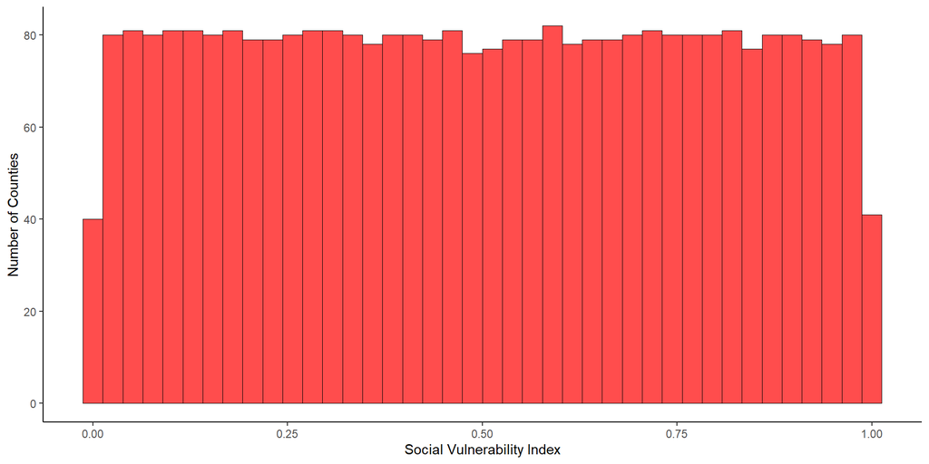

```r
# Create a histogram of CASES14DR
ggplot(us_svi,                  ## R object
       aes(x = RPL_THEMES)) +   ## Column in object
  geom_histogram(na.rm = TRUE,  ## Add histogram bars without NA warning
                 bins = 40,     ## Add histogram bars
                 fill = "red",  ## Fill color of histogram bars
                 col = "black", ## Line color of histogram bars
                 size = 0.25,   ## Line weight/thickness of historam bars
                 alpha = 0.7) + ## Fill transparency
  labs(x = "Social Vulnerability Index",     ## X axis label
       y = "Number of Counties") +           ## Y axis label
  theme_classic()                            ## Apply theme
```

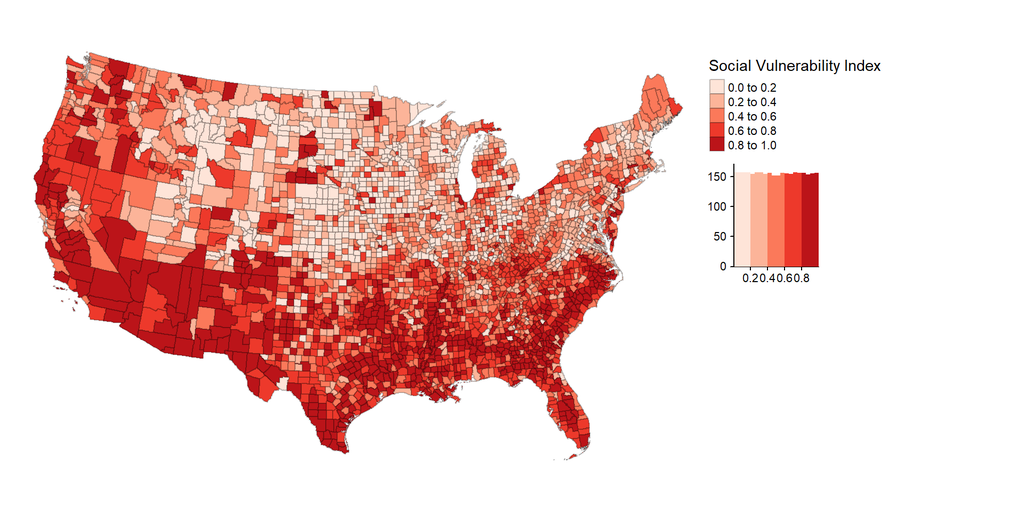

```r
# Make a quick choropleth map of CASES14DR
tm_shape(us_svi,
         projection = "ESRI:102003") +
  tm_polygons("RPL_THEMES",
              title = "Social Vulnerability Index",
              style = "pretty",
              palette = "Reds",
              border.col = "Black",
              border.alpha = 0.25,
              legend.hist = TRUE) +
  tm_layout(frame = FALSE,
            legend.outside = TRUE)
```

The histogram shows an evenly spread distribution, meaning every value in the social vulnerability index is represented in a similar number of US counties. The map shows that the spatial distribution is not nearly as even. There are visually clear clusters of high and low values.

## ESDA - Neighbors and Neighborhoods

```r
## Subset data to ONLY observations with values!
## You must remove NAs prior to Moran's I and LISA analysis
us_svi <- us_svi |>
  filter(!is.na(RPL_THEMES))

## Create Queen case neighbors
us_nb_queen <- poly2nb(us_svi,
                       queen = TRUE)

## Print summary to screen
us_nb_queen
```

```
## Neighbour list object:
## Number of regions: 3108
## Number of nonzero links: 18120
## Percentage nonzero weights: 0.1875842
## Average number of links: 5.830116
## 4 regions with no links:
## 831 1110 2340 2840
## 5 disjoint connected subgraphs
```

```r
### Note, only print the summary of the neighbors in a report
### if you're making it part of the analysis. In general, this
### information isn't really interesting or necessary!
```

## ESDA - Spatial Autocorrelation (Moran’s I)

```r
## Convert neighbor object to weight matrix
us_wm_queen <-  nb2listw(us_nb_queen,
                         style = "B",         # B is binary (1,0)
                         zero.policy = TRUE)  # Allow obs with 0 neighbors

#
# Moran's I
#
us_svi_moran <- moran.test(us_svi$RPL_THEMES,         # Variable we're analyzing
                           listw = us_wm_queen,       # Sp weights matrix
                           alternative = "two.sided", # Clustering or Dispersion
                           randomisation = TRUE,      # Compare to randomized values
                           zero.policy = TRUE)        # Allow obs with 0 neighbors

## Summary
us_svi_moran
```

```
##
##  Moran I test under randomisation
##
## data:  us_svi$RPL_THEMES
## weights: us_wm_queen  n reduced by no-neighbour observations
##
##
## Moran I statistic standard deviate = 51.176, p-value <
## 0.00000000000000022
## alternative hypothesis: two.sided
## sample estimates:
## Moran I statistic       Expectation          Variance
##      0.5368733143     -0.0003222688      0.0001101866
```

```r
### Note:  In a report, do not print the summary of Moran's I. Extract the necessary
###        values and insert them using inline
### e.g.,  The Moran's I statistic is us_svi_moran$estimate[1]
###        The p values is us_svi_moran$p.value
```

## ESDA - Spatial Autocorrelation (LISA)

```r
#
# LISA -- Local Moran's I
#
us_svi_lisa <- localmoran(us_svi$RPL_THEMES,         # Variable we're analyzing
                          listw = us_wm_queen,       # Weights object
                          alternative = "two.sided", # Clustering or Dispersion
                          zero.policy = TRUE) |>     # Best to keep TRUE for LISA
  as_tibble() |>                                     # Better object type
  mutate(across(everything(), as.vector))            # Remove junk from localmoran output


##
## To get "nice" LISA categories for mapping
## takes a bit of work in R, unfortunately
##

# Add values required for LISA category
us_svi_lisa <- us_svi_lisa |>
  mutate(SCVAR =  scale(us_svi$RPL_THEMES) |> as.vector(),           # Original data column
         LAGVAR = lag.listw(us_wm_queen, scale(us_svi$RPL_THEMES)),  # Lag of original data column
         LISACAT = case_when(SCVAR >= 0 & LAGVAR >= 0 & `Pr(z != E(Ii))` <= 0.05 ~ 1,
                             SCVAR <= 0 & LAGVAR <= 0 & `Pr(z != E(Ii))` <= 0.05 ~ 2,
                             SCVAR >= 0 & LAGVAR <= 0 & `Pr(z != E(Ii))` <= 0.05 ~ 3,
                             SCVAR <= 0 & LAGVAR >= 0 & `Pr(z != E(Ii))` <= 0.05 ~ 4,
                             `Pr(z != E(Ii))` > 0.05 ~ 5))

# This simply adds a label based on the values
us_svi_lisa <- us_svi_lisa |>
  mutate(CATNAME = case_when(LISACAT == 1 ~ "HH",
                             LISACAT == 2 ~ "LL",
                             LISACAT == 3 ~ "HL",
                             LISACAT == 4 ~ "LH",
                             LISACAT == 5 ~ "Not Significant"))

## Quick SUMMARY of LISA output
table(us_svi_lisa$CATNAME)
```

```
##
##              HH              HL              LH              LL Not Significant
##             544              68              53             455            1984
```

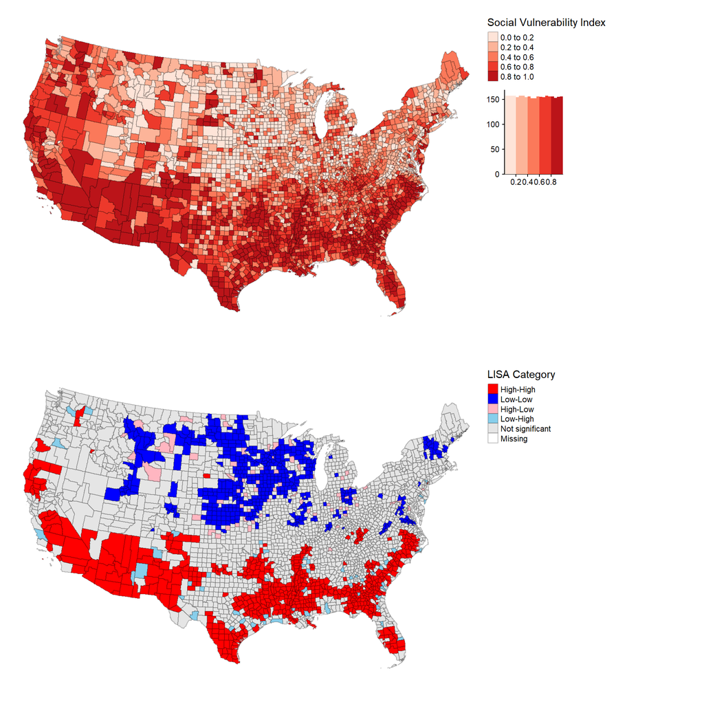

```r
### Note:  In a report, do not print the summary of LISA in the report
###        If you want to include, use inline or create a table with the info

## Add LISA category column to the spatial data
## for mapping!
us_svi <- us_svi |>
  mutate(LISACAT = us_svi_lisa$LISACAT,
         CATNAME = us_svi_lisa$CATNAME)

# Plot two maps together!
# First, the chorolpleth map
svi_tmap <- tm_shape(us_svi,
                     projection = "ESRI:102003") +
  tm_polygons("RPL_THEMES",
              title = "Social Vulnerability Index",
              style = "pretty",
              palette = "Reds",
              colorNA = "white",
              border.col = "black",
              border.alpha = 0.25,
              legend.hist = TRUE) +
  tm_layout(frame = FALSE,
            legend.outside = TRUE)

# Second the LISA map
lisa_tmap <- tm_shape(us_svi,
                      projection = "ESRI:102003") +
  tm_polygons("LISACAT",
              title = "LISA Category",
              breaks = c(1, 2, 3, 4, 5, 6),
              palette =  c("red",
                           "blue",
                           "lightpink",
                           "skyblue",
                           "grey90"),
              colorNA = "white",
              labels = c("High-High",
                         "Low-Low",
                         "High-Low",
                         "Low-High",
                         "Not significant"),
              border.col = "black",
              border.alpha = 0.25) +
  tm_layout(frame = FALSE,
            legend.outside = TRUE)

# This command maps them together!
tmap_arrange(svi_tmap,
             lisa_tmap,
             ncol = 1,
             nrow = 2)
```

The LISA output reports 544 high highs and 455 low lows. clusters of the high highs and the low lows are spatially separated, with the highs in the south and lows in the north. The social vulnerability index is very high in the south and southwest and help should be directed to those areas.